# Análisis de una serie temporal

US Energy Generation

Jesús Martínez Leal, Samuel Ortega Mediavilla & Pablo Vicente Martínez

En este caso práctico analizamos la serie temporal correspondiente a la generación de los distintos tipos de energía en Estados Unidos. Cargamos los paquetes de R que vamos a utilizar en el análisis e inicializamos el entorno.

```r
rm(list = ls()) # borrado de variables previas
library(readr)
library(forecast)
library(ggplot2)
library(dplyr)
library(astsa)
library(knitr)
```

Seteamos algunas constantes útiles, en este caso, las etiquetas de los ejes de las representaciones gráficas van a ser constantes en la mayoría de gráficos.

```r
x_label <- "Tiempo / años"
y_label <- "Energía generada / MWh"
y_label_log <- " log(Energía generada / MWh)"
```

Para hacernos una idea de los datos que tenemos, lo mejor que podemos hacer es representarlos. Tras cargar el dataset, generamos una gráfica coon todos los tipos de energía.

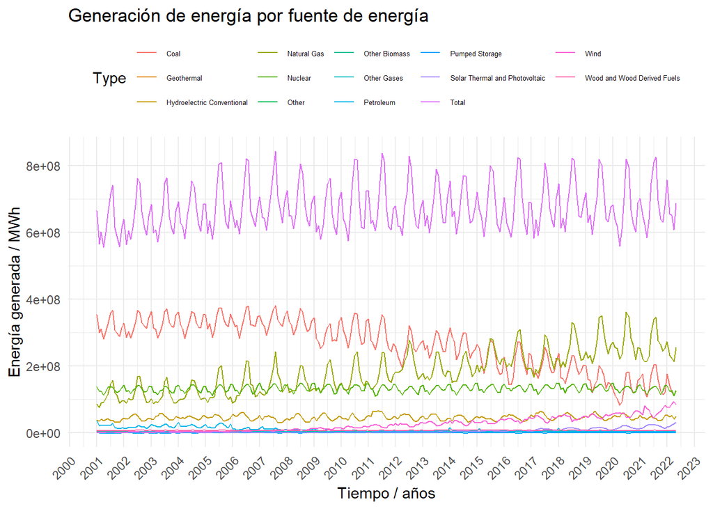

```r
# Cargamos el csv con los datos generación de energía en US
Dat <- read.csv(file = "./data/organised_Gen.csv", header = TRUE, sep = ",", dec = ".")

# Eliminamos la columna de indices
Dat <- Dat %>%
  select(-X)

# Construimos la columna date
Dat <- Dat %>%
  mutate(date = as.Date(paste(YEAR, MONTH, "01", sep = "-"), format = "%Y-%m-%d")) %>%
  select(date, everything()) %>%
  select(-YEAR, -MONTH) %>%
  rename(gen.MWh = GENERATION..Megawatthours.)

# Eliminamos datos mal formateados
Dat <- na.omit(Dat)

# Nos quedamos con el total de US
Total_gen <- filter(Dat, STATE == "US-TOTAL")

# Calculamos el total por cada fuente de energía
total_by_source <- Total_gen %>%
  group_by(date, ENERGY.SOURCE) %>%
  summarise(across(where(is.numeric), sum)) %>%
  ungroup()

ggplot(total_by_source, aes(x = date, y = gen.MWh, color = ENERGY.SOURCE)) +
  geom_line() +
  scale_x_date(date_labels = "%Y", date_breaks = "1 year") +
  theme_minimal() +
  labs(
    title = "Generación de energía por fuente de energía",
    x = x_label,
    y = y_label,
    color = "Type"
  )  +
  theme(axis.text.x = element_text(angle = 45, hjust = 1)) +
  theme(legend.position = "top", legend.box = "horizontal", legend.text = element_text(size = 5)) +
  guides(color = guide_legend(title = "Type"))
```

Ahora elegimos la fuente de energía a estudiar.

# 1 Energía total

```r
sel_energia <- "Total"
switch(sel_energia,
       "Solar Thermal and Photovoltaic" = {
         energy_source_label <- "Energía solar-térmica y fotovoltaica"
       },
       "Wind" = {
         energy_source_label <- "Energía eólica"
       },
       "Total" = {
         energy_source_label <- "Energía total"
       },
       {
         energy_source_label <- sel_energia
       })

energy_source_df_all <- filter(total_by_source, ENERGY.SOURCE == sel_energia) %>%
  select(-ENERGY.SOURCE)

#Seleccionamos el periodo de tiempo a estudiar

start_idx <- which(energy_source_df_all$date == "2012-01-01")
end_idx <- which(energy_source_df_all$date == "2021-12-01")

energy_source_df <- energy_source_df_all[start_idx:end_idx,]
head(energy_source_df)
```

| date | gen.MWh |
| --- | --- |
| 2012-01-01 | 679056519 |
| 2012-02-01 | 618778840 |
| 2012-03-01 | 618181138 |
| 2012-04-01 | 590456433 |
| 2012-05-01 | 673035262 |
| 2012-06-01 | 721652302 |

```r
#Generamos la serie temporal

energy_source_ts <- ts(data = energy_source_df$gen.MWh, start = c(2012, 01), frequency = 12)
```

## 1.1 Descripción gráfica de la serie temporal

Es habitual comenzar el análisis de una serie con la representación gráfica de los valores observados de la variable de interés en función del tiempo:

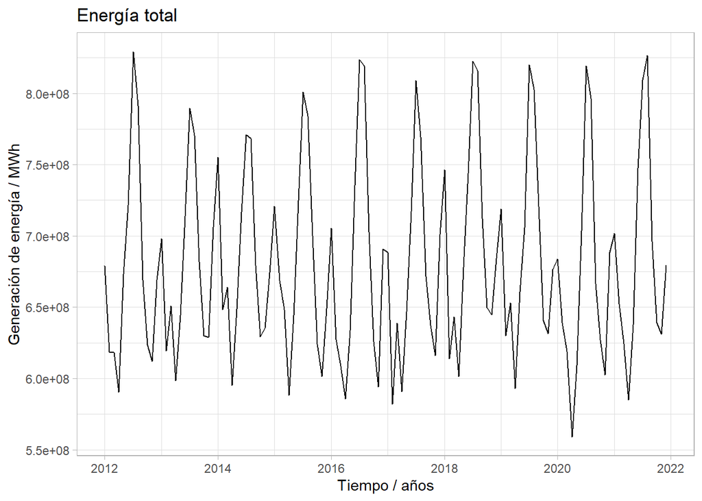

```r
autoplot(energy_source_ts, xlab = "Tiempo / años", ylab = "Generación de energía / MWh") +
  ggtitle(energy_source_label) +
  theme_light()
```

A partir del gráfico temporal podemos apreciar carencia de *tendencia*: la energía total no presenta ni una evolución al alza o a la baja a lo largo del tiempo. Por otro lado, se observa un comportamiento cíclico que se repite año tras año (*estacionalidad*), con una mayor generación de energía durante los meses de verano. La longitud del ciclo estacional es $c = 12$.

En este ejemplo, la estacionalidad de la serie se observa claramente en el gráfico temporal. No obstante, el diagrama de cajas por mes nos permite también valorar la presencia de estacionalidad.

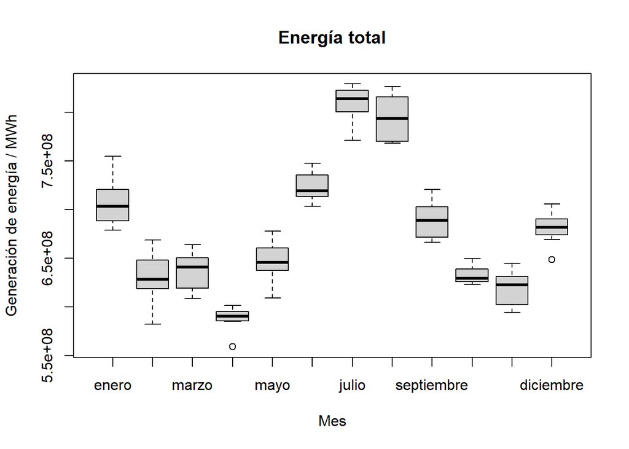

```r
energy_source_df <- energy_source_df %>%
  mutate(mes = format(date, "%B"))

energy_source_df$mes <- factor(energy_source_df$mes,
                       levels = c("enero", "febrero", "marzo", "abril", "mayo", "junio",
                                  "julio", "agosto", "septiembre", "octubre", "noviembre", "diciembre"))

# Ordenamos los meses para que los represente por orden temporal

boxplot(energy_source_df$gen.MWh ~ energy_source_df$mes, xlab = "Mes", ylab = "Generación de energía / MWh", main = energy_source_label)
```

Una gráfica estacional es similar a una gráfica temporal, excepto que los datos se dibujan contra las “estaciones” individuales en las que se observaron los datos. A continuación se ofrece un ejemplo:

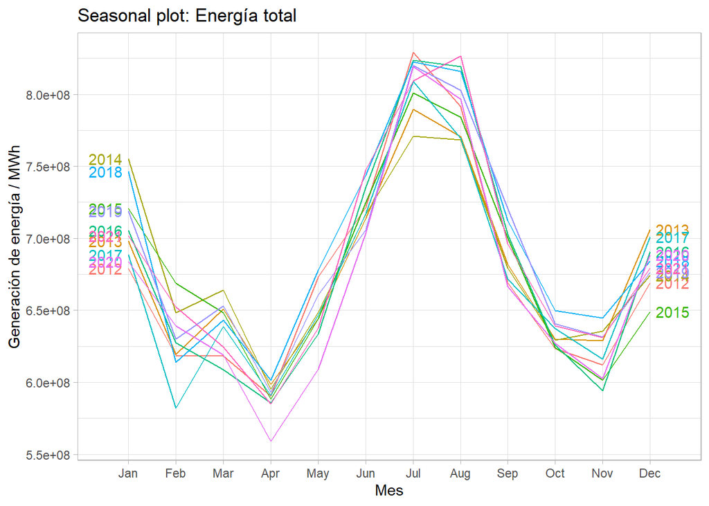

```r
ggseasonplot(energy_source_ts, year.labels = TRUE, year.labels.left = TRUE) +
  xlab("Mes")+
  ylab("Generación de energía / MWh") +
  ggtitle(paste("Seasonal plot:", energy_source_label)) +
  theme_light()
```

## 1.2 Análisis de la serie mediante suavizado exponencial

Dadas las características de la serie temporal (solo presenta estacionalidad) el método adecuado para su análisis es el de Holt-Winters (ya que este podría tratar una posible tendencia difícil de observar a simple vista, sirviendo de generalización.)

Compararemos los resultados obtenidos a partir del método Holt-Winters aditivo, Holt-Winters multiplicativo, así como del Holt-Winters aditivo pero aplicado a la serie transformada (con logaritmo).

Utilizamos los datos hasta diciembre de 2020 para el ajuste y reservamos las observaciones de 2021 para valorar la capacidad predictiva del método seleccionado. La predicción para el año 2021 la realizaremos utilizando el método que nos proporcione un mejor ajuste.

### 1.2.1 Holt-Winters aditivo

Este método aditivo agrega el factor de estacionalidad a la previsión con tendencia, tal y como se vio en clase.

```r
insample <- window(energy_source_ts, start = c(2012,1), end = c(2020,12))
outsample <- window(energy_source_ts, start = c(2021,1), end = c(2021,12))

energy_source_HW_add <- HoltWinters(insample, seasonal="additive")
energy_source_HW_add$coefficients
```

```
##           a           b          s1          s2          s3          s4
## 678397494.0   -358376.4  24828864.8 -55614833.3 -41641417.1 -89303752.3
##          s5          s6          s7          s8          s9         s10
## -29046356.3  44552943.3 142103200.8 119945763.2  11565750.4 -47254572.2
##         s11         s12
## -63939563.9    276065.2
```

```r
energy_source_HW_add$alpha
```

```
##     alpha
## 0.4268915
```

```r
energy_source_HW_add$beta
```

```
## beta
##    0
```

```r
energy_source_HW_add$gamma
```

```
##     gamma
## 0.3511327
```

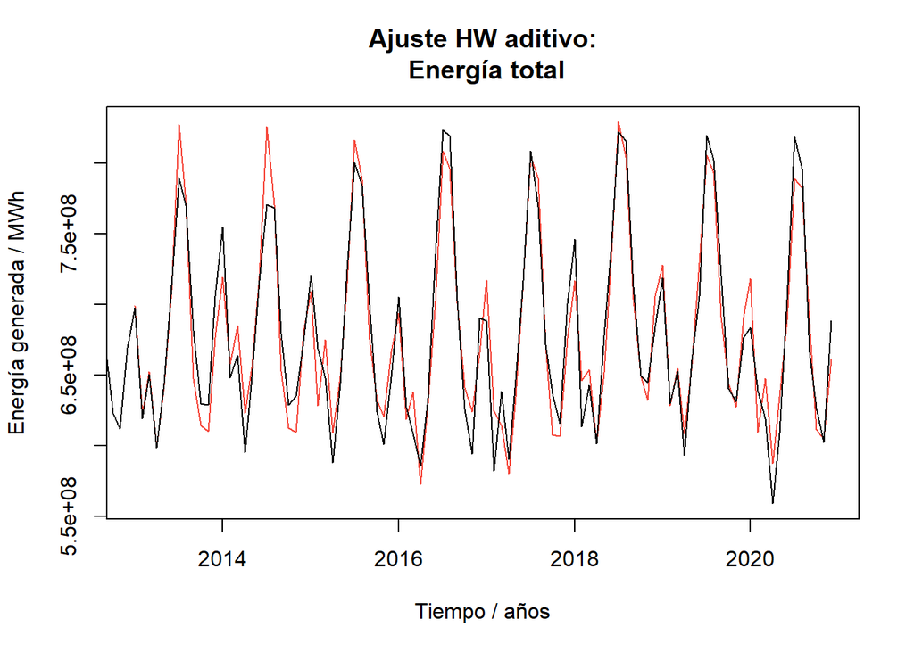

```r
fitval_add <- fitted(energy_source_HW_add)
# fitval contiene la serie de valores ajustados en la primera columna (fitval_add[,1] = xhat)

plot(energy_source_HW_add, xlab = x_label, ylab = y_label,
     main = paste("Ajuste HW aditivo:\n", energy_source_label))
```

```r
# Valoramos la bondad del ajuste
insamplecut <- window(insample, start = c(2013,1), end = c(2020,12))
# El año 2012 se utiliza para calcular las condiciones iniciales.
# El ajuste pues se obtiene a partir de enero de 2013.

rmse_add <- sqrt(mean( (insamplecut - fitval_add[,1]) ^ 2 ))
mape_add <- 100 * mean( abs(insamplecut - fitval_add[,1]) / insamplecut )
```

### 1.2.2 Holt-Winters multiplicativo

En este caso el factor de estacionalidad aparece multiplicando a la previsión con tendencia: de ahí el nombre del método.

```r
energy_source_HW_mult <- HoltWinters(insample, seasonal = "multiplicative")
energy_source_HW_mult$coefficients
```

```
##             a             b            s1            s2            s3
##  6.789064e+08 -3.583764e+05  1.034395e+00  9.174092e-01  9.369261e-01
##            s4            s5            s6            s7            s8
##  8.666777e-01  9.568900e-01  1.067138e+00  1.211597e+00  1.177595e+00
##            s9           s10           s11           s12
##  1.016988e+00  9.307933e-01  9.054970e-01  9.998977e-01
```

```r
energy_source_HW_mult$alpha
```

```
##     alpha
## 0.4408653
```

```r
energy_source_HW_mult$beta
```

```
## beta
##    0
```

```r
energy_source_HW_mult$gamma
```

```
##     gamma
## 0.3816109
```

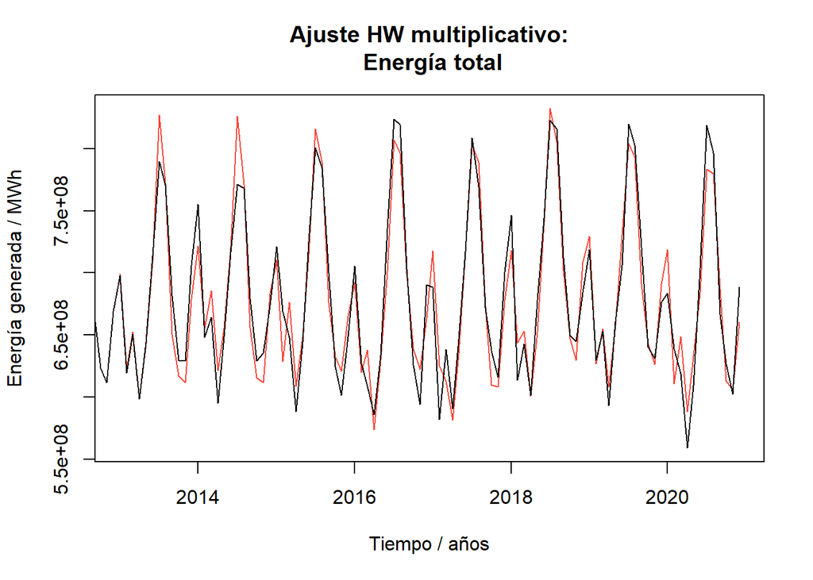

```r
fitval_mult <- fitted(energy_source_HW_mult)

plot(energy_source_HW_mult, xlab = x_label, ylab = y_label,
     main = paste("Ajuste HW multiplicativo:\n", energy_source_label))
```

```r
# Valoramos la bondad del ajuste
rmse_mult <- sqrt(mean( (insamplecut - fitval_mult[,1]) ^ 2 ))
mape_mult <- 100*mean( abs(insamplecut - fitval_mult[,1]) / insamplecut )
```

### 1.2.3 Holt-Winters aditivo aplicado a la serie transformada

Una alternativa al método multiplicativo consiste en realizar previamente una transformación logarítmica a los datos. La serie logarítmica se analiza con el método de Holt-Winters aditivo. A las predicciones obtenidas se les aplica una transformación exponencial para regresar a las unidades originales.

```r
loginsample <- log(insample)

energy_source_HW_log_add <- HoltWinters(loginsample, seasonal = "additive")
energy_source_HW_log_add$coefficients
```

```
##             a             b            s1            s2            s3
## 20.3290434835 -0.0003440763  0.0394167345 -0.0816769981 -0.0588924786
##            s4            s5            s6            s7            s8
## -0.1374493804 -0.0402718328  0.0681225144  0.1955358432  0.1678000475
##            s9           s10           s11           s12
##  0.0211358299 -0.0675412739 -0.0942740585  0.0045134474
```

```r
energy_source_HW_log_add$alpha
```

```
##     alpha
## 0.3970642
```

```r
energy_source_HW_log_add$beta
```

```
## beta
##    0
```

```r
energy_source_HW_log_add$gamma
```

```
##     gamma
## 0.3253039
```

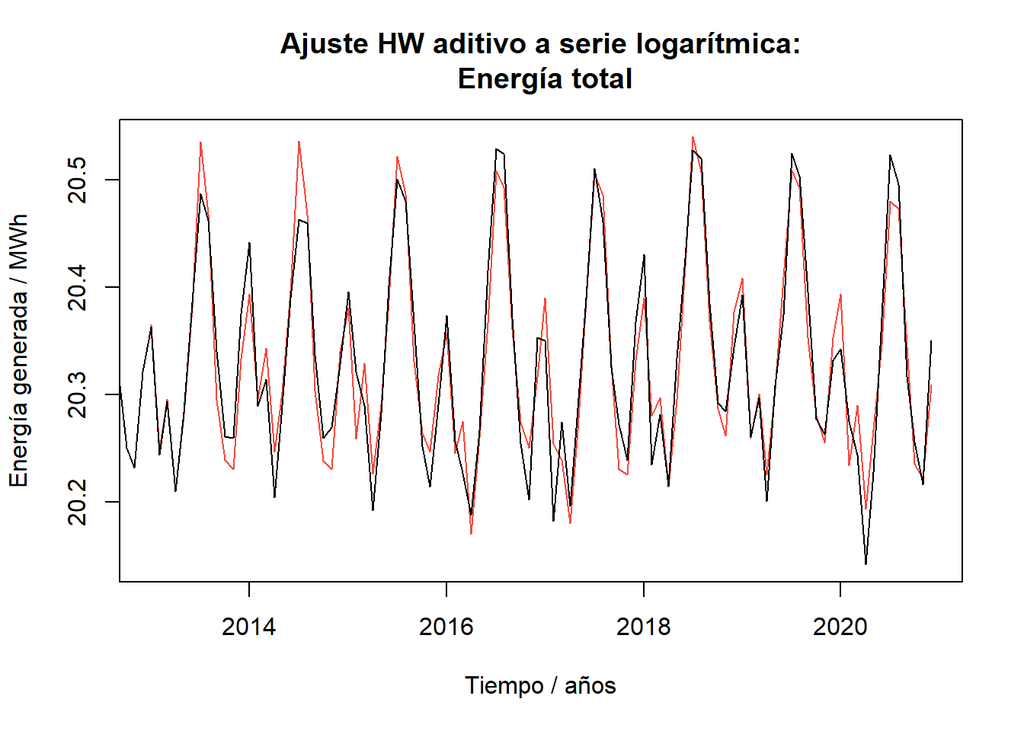

```r
fitval_log <- fitted(energy_source_HW_log_add)

plot(energy_source_HW_log_add, xlab = x_label, ylab = y_label,
     main = paste("Ajuste HW aditivo a serie logarítmica:\n", energy_source_label))
```

```r
# Valoramos la bondad del ajuste. Para ello, volvemos previamente a la escala original

fitval_ori <- exp(fitval_log[,1])

rmse_log <- sqrt(mean( (insamplecut - fitval_ori) ^ 2 ))
mape_log <- 100*mean( abs(insamplecut - fitval_ori) / insamplecut )
```

### 1.2.4 Construcción de la Tabla de resultados obtenidos con los distintos métodos

```r
error_ajuste <- matrix(c(rmse_add, mape_add, rmse_mult, mape_mult, rmse_log, mape_log), nrow = 3, byrow = TRUE)
rownames(error_ajuste) <- c("Aditivo", "Multiplicativo", "Log-Aditivo")
colnames(error_ajuste) <- c("RMSE / MWh", "MAPE / %")
kable(error_ajuste, caption = "Tabla 1. Resultados obtenidos con los distintos métodos de suavizado", align = "c")
```

Tabla 1. Resultados obtenidos con los distintos métodos de suavizado

|  | RMSE / MWh | MAPE / % |
| --- | --- | --- |
| Aditivo | 20255079 | 2.427754 |
| Multiplicativo | 20152770 | 2.419434 |
| Log-Aditivo | 20194480 | 2.416326 |

Como podemos observar, el RMSE es más pequeño en el caso multiplicativo, pero el MAPE es ligeramente menor en el caso logarítmico aditivo. Dado que la serie temporal admitimos que carece de heterocedasticidad, el método que usaremos para realizar la predicción del año 2021 será el Holt-Winters con estacionalidad **multiplicativa**.

### 1.2.5 Selección del mejor método para realizar la predicción

El método escogido es el Holt-Winters multiplicativo por lo que se comentó anteriormente.

```r
# Elegimos el HW a usar
energy_source_HW <- energy_source_HW_mult

pred <- predict(energy_source_HW, 12)

# Valoramos la capacidad predictiva del método
rmse_pred <- sqrt(mean( (outsample - pred) ^ 2 ))
mape_pred <- 100 * mean( abs(outsample - pred) / outsample )

cat("Predicción para 2021:\nRMSE:", rmse_pred, "MWh", "\nMAPE:", mape_pred, "%\n")
```

```
## Predicción para 2021:
## RMSE: 16904653 MWh
## MAPE: 1.959043 %
```

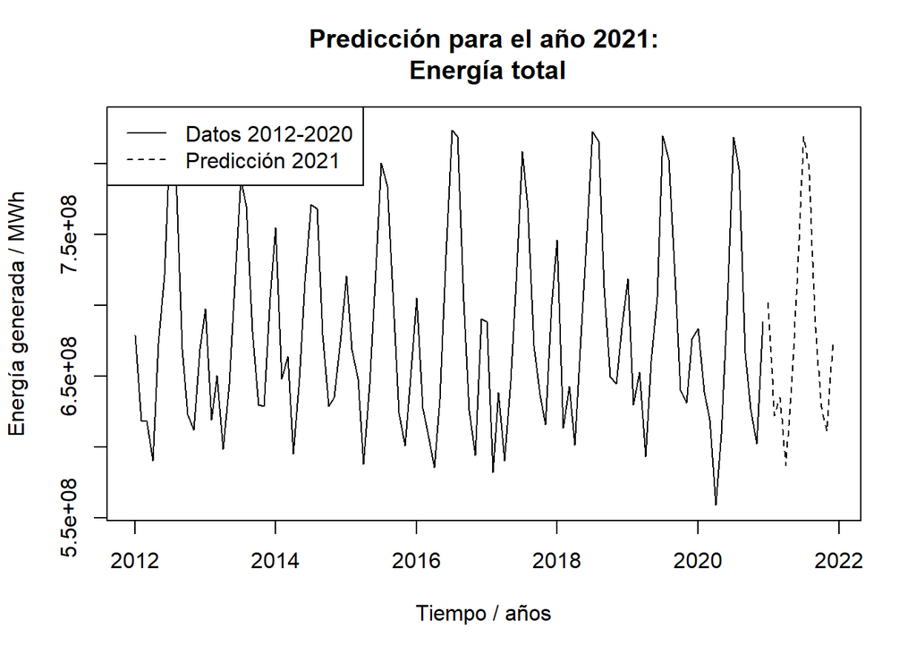

```r
# pred contiene las predicciones puntuales para los 12 meses de 2021
ts.plot(insample, pred, lty = 1:2,
        gpars = list(xlab = x_label, ylab = y_label,
                     main = paste("Predicción para el año 2021:\n", energy_source_label)))
legend("topleft", legend = c("Datos 2012-2020", "Predicción 2021"),
       lty = c(1, 2))
```

Podemos también representar gráficamente los valores reales de 2021 que habíamos reservado junto con la predicción puntual:

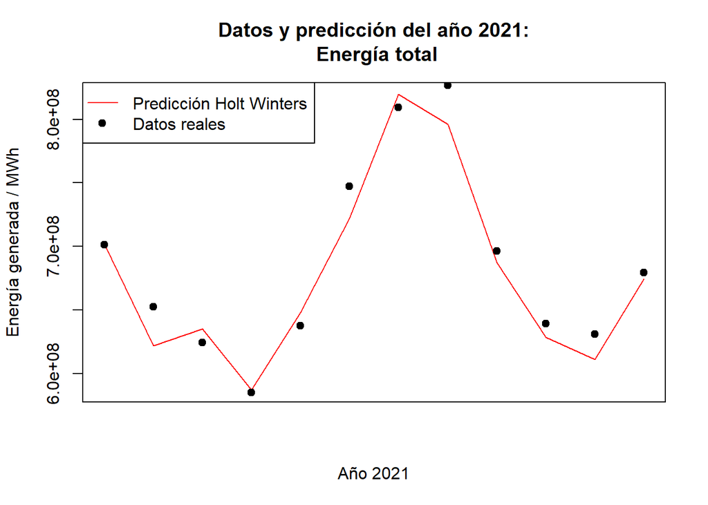

```r
plot(pred, col = "red", xaxt = "n", xlab = "Año 2021", ylab = y_label,
     main = paste("Datos y predicción del año 2021:\n", energy_source_label))
points(outsample, pch = 19)
legend("topleft", legend = c("Predicción Holt Winters", "Datos reales"),
       col = c("red", "black"), pch = c(NA, 19), lty = c(1, 0))
```

Podemos observar cómo nuestra predicción queda muy cerca de todos los datos reales, dando por satisfactorio nuestro resultado obtenido.

Así mismo, es posible determinar el intervalo de predicción al 95% en nuestro modelo, tal y como se muestra en la siguiente Figura.

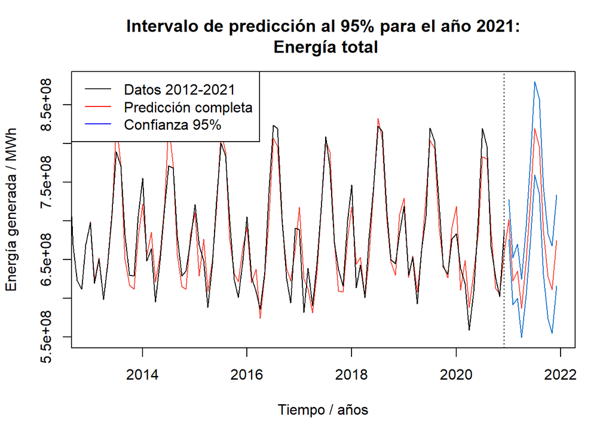

```r
pred <- predict(energy_source_HW, n.ahead = 12, prediction.interval = TRUE, level = 0.95)
plot(energy_source_HW, pred, xlab = x_label, ylab = y_label,
     main = paste("Intervalo de predicción al 95% para el año 2021:\n", energy_source_label))
legend("topleft", legend = c("Datos 2012-2021", "Predicción completa", "Confianza 95%"),
       col = c("black", "red", "blue"), lty = 1)
```

## 1.3 Análisis de la serie mediante la metodología Box-Jenkins

Con la metodología Box-Jenkins la idea es describir el valor observado en un período *t* como una función lineal de valores anteriores y errores debidos al azar.

### 1.3.1 Transformación estacionaria de la serie

El primer paso en esta metodología es determinar la transformación estacionaria de la serie.

En primera instancia, calculamos una diferencia estacional ($D = 1$):

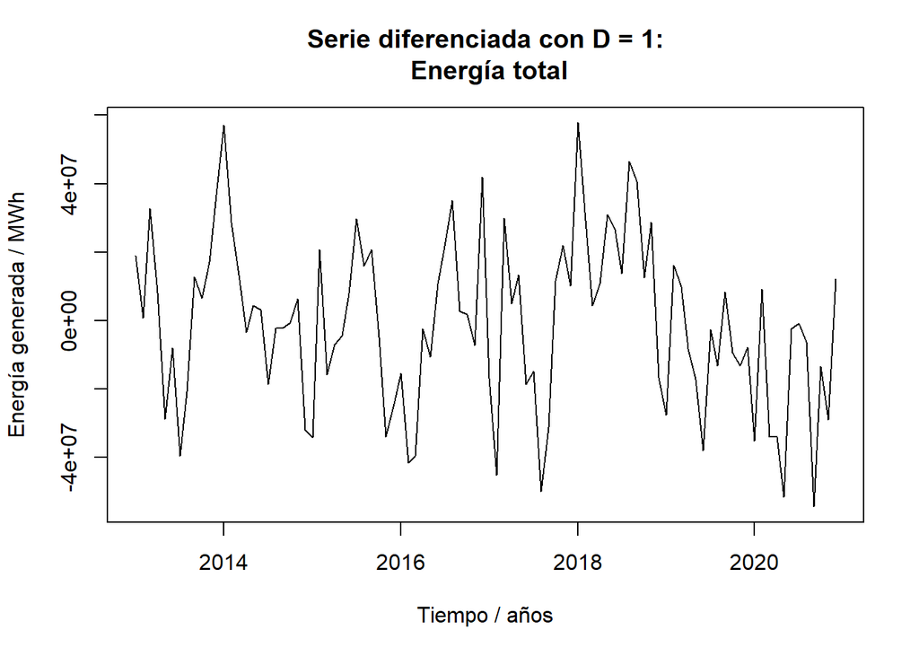

```r
d12insample <- diff(insample, 12)
plot(d12insample, xlab = x_label, ylab = y_label,
     main = paste("Serie diferenciada con D = 1:\n", energy_source_label))
```

Parece que hemos quitado la estacionalidad. A simple vista, como ya hemos comentado, parece que no existe tendencia en nuestra serie, pero para asegurar un correcto análisis de los datos diferenciaremos una segunda vez. En caso de que esta segunda diferenciación no fuese necesaria se haría evidente a la hora de utilizar los modelos predictivos.

Calculamos pues una diferencia regular ($d = 1$):

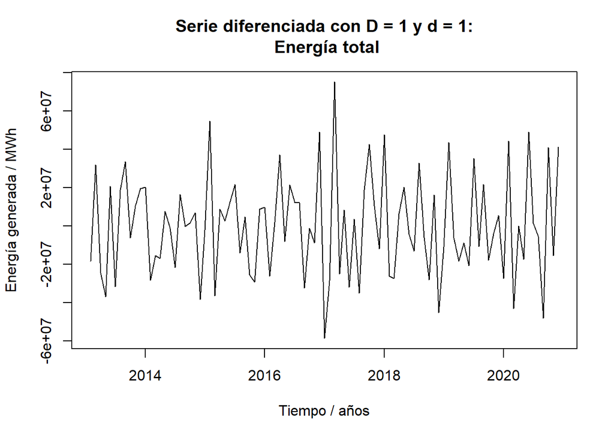

```r
dd12insample <- diff(d12insample)
plot(dd12insample, xlab = x_label, ylab = y_label,
     main = paste("Serie diferenciada con D = 1 y d = 1:\n", energy_source_label))
```

Podemos asumir que la serie diferenciada con $d = 1$ y $D = 1$ ya es estacionaria.

### 1.3.2 Identificación de un modelo basado en análisis de autocorrelaciones y autocorrelaciones parciales

Pasamos a examinar el correlograma y el correlograma parcial:

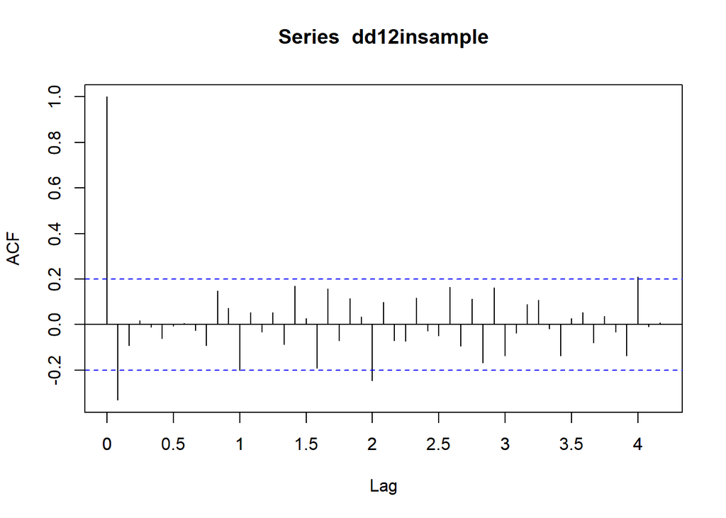

```r
acf_result <- acf(dd12insample,lag.max = 50, plot = FALSE)

plot(acf_result)
custom_xticks <- seq(0, 5, by = 0.5)
axis(1, at = custom_xticks, labels = custom_xticks)
```

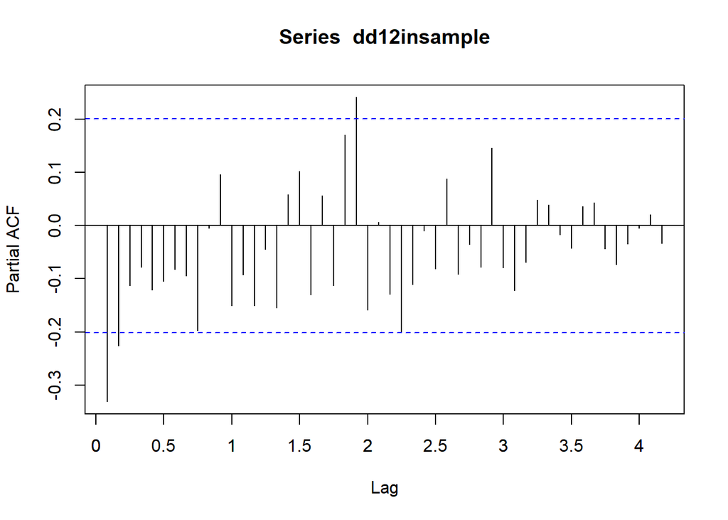

```r
pacf_result <- pacf(dd12insample,lag.max = 50, plot = FALSE)
plot(pacf_result)
custom_xticks <- seq(0, 5, by = 0.5)
axis(1, at = custom_xticks, labels = custom_xticks)
```

Por otra parte, si nos fijamos en los retardos estacionales (Lag = 1, 2, 3, 4 ciclos estacionales), podemos pensar:

- La función de autocorrelación muestra decrecimiento, mientras que la función de autocorrelación parcial podemos considerar que tiene el primer coeficiente significativo: (P,D,Q) = (0,1,1)
- La función de autocorrelación muestra decrecimiento, mientras que la de autocorrelación parcial tiene los dos primeros coeficientes significativos: (P,D,Q) = (0,1,2)

Veamos el ajuste proporcionado por los distintos modelos:

**Modelo 1.**

```r
source_energy_model_1 <- arima(insample, order = c(2,1,2), seasonal = list(order=c(0,1,2), period=12))
source_energy_model_1
```

```
##
## Call:
## arima(x = insample, order = c(2, 1, 2), seasonal = list(order = c(0, 1, 2),
##     period = 12))
##
## Coefficients:
##          ar1     ar2      ma1     ma2     sma1     sma2
##       0.5308  0.0127  -1.1181  0.1182  -0.6895  -0.3103
## s.e.  0.8721  0.4006   0.8681  0.8653   0.1733   0.1278
##
## sigma^2 estimated as 2.87e+14:  log likelihood = -1729.51,  aic = 3473.02
```

```r
#Modelo 1: p values

source_energy_model_1s <- sarima(dd12insample,2,1,2,0,1,2,12, details = FALSE)
source_energy_model_1s$ttable
```

```
##      Estimate     SE  t.value p.value
## ar1    0.4512 0.1339   3.3692  0.0012
## ar2    0.0824 0.1215   0.6782  0.4997
## ma1   -1.9165 0.0666 -28.7616  0.0000
## ma2    0.9353 0.0693  13.4905  0.0000
## sma1  -1.6555 1.0801  -1.5328  0.1295
## sma2   0.6693 0.9860   0.6788  0.4993
```

**Modelo 2.**

```r
source_energy_model_2 <- arima(insample, order = c(1,1,2), seasonal = list(order = c(0,1,1), period=12))
source_energy_model_2
```

```
##
## Call:
## arima(x = insample, order = c(1, 1, 2), seasonal = list(order = c(0, 1, 1),
##     period = 12))
##
## Coefficients:
##          ar1      ma1     ma2     sma1
##       0.5579  -1.1140  0.1140  -1.0000
## s.e.  0.1783   0.2163  0.2062   0.1599
##
## sigma^2 estimated as 2.84e+14:  log likelihood = -1731.53,  aic = 3473.07
```

```r
#Modelo 2: p values
source_energy_model_2s <- sarima(dd12insample,1,1,2,0,1,1,12, details = FALSE)
source_energy_model_2s$ttable
```

```
##      Estimate     SE  t.value p.value
## ar1    0.3817 0.1537   2.4839  0.0151
## ma1   -1.8914 0.1358 -13.9241  0.0000
## ma2    0.8945 0.1140   7.8444  0.0000
## sma1  -0.9992 0.1677  -5.9577  0.0000
```

**Modelo 3.**

```r
source_energy_model_3 <- arima(insample, order = c(1,0,2), seasonal = list(order = c(0,1,1), period = 12))
source_energy_model_3
```

```
##
## Call:
## arima(x = insample, order = c(1, 0, 2), seasonal = list(order = c(0, 1, 1),
##     period = 12))
##
## Coefficients:
##          ar1      ma1     ma2     sma1
##       0.4923  -0.0637  0.0319  -0.9999
## s.e.  0.2710   0.2767  0.1549   0.1503
##
## sigma^2 estimated as 2.817e+14:  log likelihood = -1746.56,  aic = 3503.13
```

```r
#Modelo 3: p values
source_energy_model_3s <- sarima(dd12insample,1,0,2,0,1,1,12, details = FALSE)
source_energy_model_3s$ttable
```

```
##            Estimate         SE t.value p.value
## ar1          0.5584     0.2176  2.5661  0.0122
## ma1         -1.1759     0.2704 -4.3491  0.0000
## ma2          0.1769     0.2533  0.6985  0.4870
## sma1        -0.9998     0.1664 -6.0094  0.0000
## constant -7840.8113 12435.1137 -0.6305  0.5302
```

**Modelo predicho por Auto-Arima.**

```r
source_energy_model_auto <- auto.arima(insample)
source_energy_model_auto
```

```
## Series: insample
## ARIMA(1,0,0)(2,1,0)[12]
##
## Coefficients:
##          ar1     sar1     sar2
##       0.3844  -0.3422  -0.4685
## s.e.  0.0961   0.1055   0.0973
##
## sigma^2 = 3.829e+14:  log likelihood = -1749.86
## AIC=3507.72   AICc=3508.16   BIC=3517.98
```

El modelo de menor AIC (con p-values aceptables menores a 0.05) es (p,d,q)(P,D,Q) = (1,1,2)(0,1,1), que no coincide con el modelo proporcionado por la función `auto.arima`.

Los estadísticos relacionados con el modelo 2 son:

```
##                    ME     RMSE      MAE        MPE     MAPE      MASE
## Training set -1651211 15807426 12109588 -0.3262272 1.811716 0.2173222
##                    ACF1
## Training set -0.0111321
```

Veamos a continuación la representación gráfica del ajuste obtenido. Línea negra: valores reales, línea roja: valores ajustados.

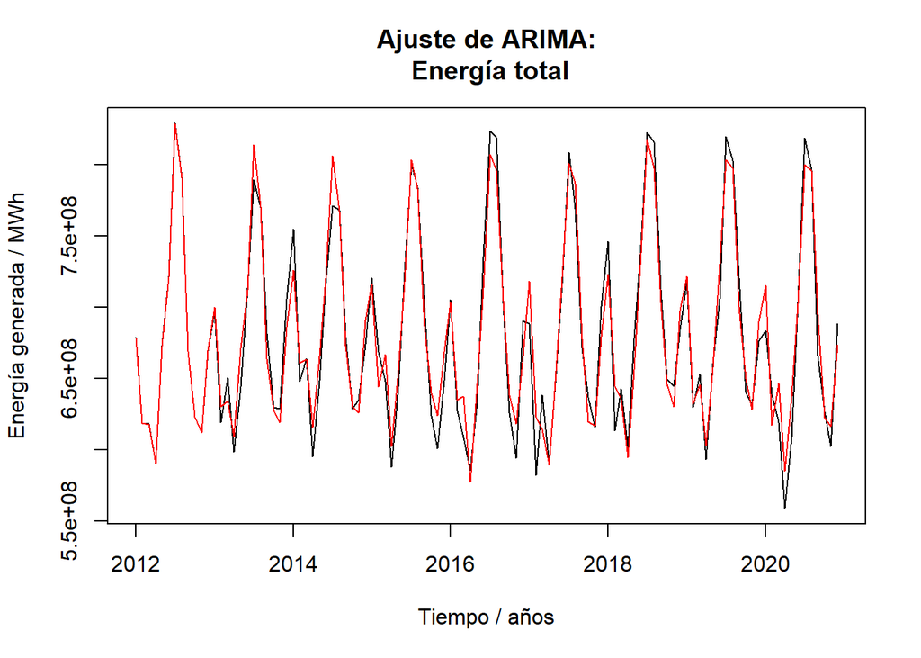

```r
# Elegimos modelo
source_energy_model <- source_energy_model_2
fitval <- fitted(source_energy_model)

plot(insample, xlab = x_label, ylab = y_label,
     main = paste("Ajuste de ARIMA:\n", energy_source_label))
lines(fitval, col = "red")
```

Antes de pasar a la predicción, comprobamos que el modelo es válido. Como muestran las siguientes salidas, los residuos del modelo pueden considerarse ruido blanco.

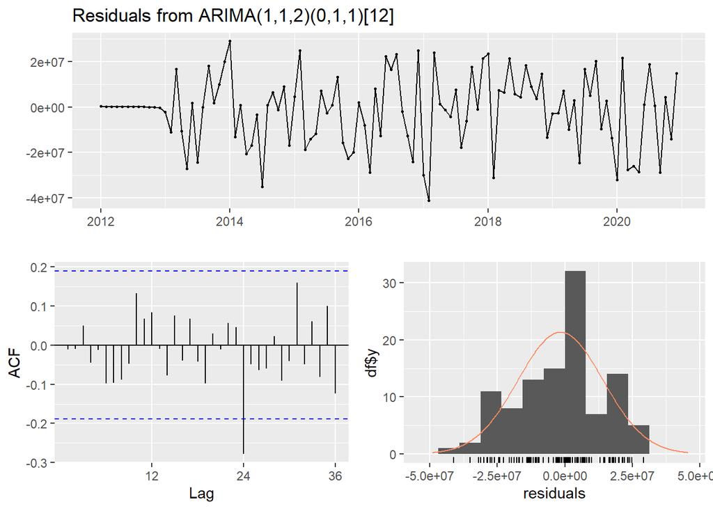

```
##
##  Ljung-Box test
##
## data:  Residuals from ARIMA(1,1,2)(0,1,1)[12]
## Q* = 11.891, df = 18, p-value = 0.8528
##
## Model df: 4.   Total lags used: 22
```

```r
checkresiduals(source_energy_model, plot=TRUE)
```

La predicción obtenida para los 12 meses de 2021 junto con el error de predicción vienen dados por:

```r
pred <- forecast(source_energy_model, h = 12)$mean
pred # Predicción puntual
```

```
##            Jan       Feb       Mar       Apr       May       Jun       Jul
## 2021 715514581 631634135 641978162 592708802 652046391 723542663 812639043
##            Aug       Sep       Oct       Nov       Dec
## 2021 794077365 692477016 634659517 620893967 683864474
```

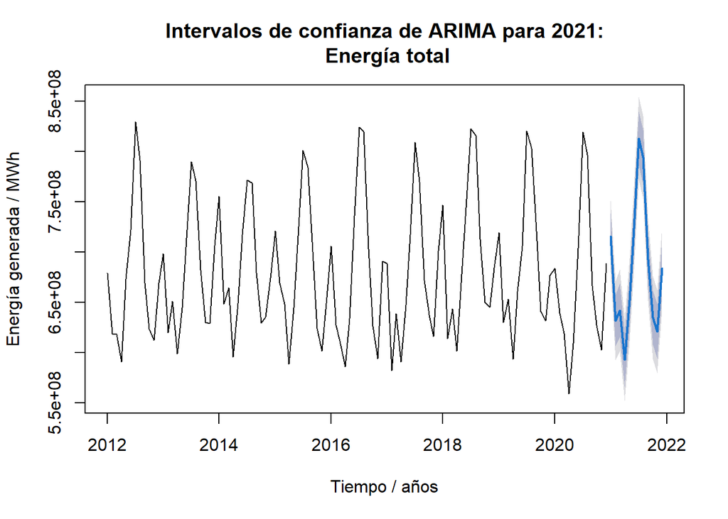

```r
plot(forecast(source_energy_model,h=12), xlab = x_label, ylab = y_label,
     main = paste("Intervalos de confianza de ARIMA para 2021:\n", energy_source_label))
```

```r
rmse_pred <- sqrt(mean((outsample-pred)^2))
mape_pred <- 100*mean(abs(outsample-pred)/outsample)

cat("Predicción para 2021:\nRMSE:", rmse_pred, "MWh", "\nMAPE:", mape_pred, "%\n")
```

```
## Predicción para 2021:
## RMSE: 15817957 MWh
## MAPE: 1.8845 %
```

Finalmente, representamos gráficamente los valores reales de 2021 que habíamos reservado junto con la predicción puntual:

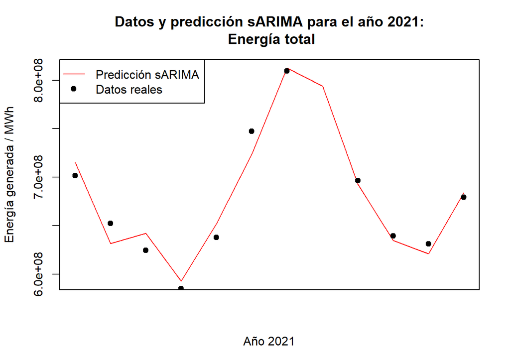

```r
plot(pred, col="red",xaxt="n", xlab = "Año 2021", ylab = y_label,
     main = paste("Datos y predicción sARIMA para el año 2021:\n", energy_source_label))
points(outsample,pch=19)
legend("topleft", legend = c("Predicción sARIMA", "Datos reales"),
       col = c("red", "black"), pch = c(NA, 19), lty = c(1, 0))
```

En la siguiente Tabla se recogen los errores RMSE y MAPE de suavizado exponencial con Holt-Winters y con el modelo de sARIMA.

```r
tabla_comparacion <- matrix(c(16904653, 1.959043, 15817957, 1.8845), nrow = 2, byrow = TRUE)
rownames(tabla_comparacion) <- c("Holt-Winters (multiplicativo)", "sARIMA")
colnames(tabla_comparacion) <- c("RMSE / MWh", "MAPE / %")
kable(tabla_comparacion, caption = "Tabla 2. Comparación entre modelo de Holt-Winters y de sARIMA", align = "c")
```

Tabla 2. Comparación entre modelo de Holt-Winters y de sARIMA

|  | RMSE / MWh | MAPE / % |
| --- | --- | --- |
| Holt-Winters (multiplicativo) | 16904653 | 1.959043 |
| sARIMA | 15817957 | 1.884500 |

Si comparamos ambas metodologías, vemos que el error de ajuste correspondiente al modelo sARIMA es menor que el obtenido con Holt-Winters multiplicativo y, por tanto, como predicción para el año 2021 deberíamos haber tomado las obtenidas con la metodología Box-Jenkins. Además, como habíamos reservado las observaciones de 2021 para valorar la capacidad predictiva del modelo, comprobamos que las predicciones obtenidas con el modelo sARIMA son, también, más precisas (menor error de predicción).

# 2 Solar

Repetimos para la energía solar, que tiene tendencia y heterocedasticidad, además de estacionalidad.

```r
sel_energia <- "Solar Thermal and Photovoltaic"
switch(sel_energia,
       "Solar Thermal and Photovoltaic" = {
         energy_source_label <- "Energía solar-térmica y fotovoltaica"
       },
       "Wind" = {
         energy_source_label <- "Energía eólica"
       },
       "Total" = {
         energy_source_label <- "Energía total"
       },
       {
         energy_source_label <- sel_energia
       })

energy_source_df_all <- filter(total_by_source, ENERGY.SOURCE == sel_energia) %>%
  select(-ENERGY.SOURCE)

#Seleccionamos el periodo de tiempo a estudiar

start_idx <- which(energy_source_df_all$date == "2012-01-01")
end_idx <- which(energy_source_df_all$date == "2021-12-01")

energy_source_df <- energy_source_df_all[start_idx:end_idx,]
head(energy_source_df)
```

| date | gen.MWh |
| --- | --- |
| 2012-01-01 | 190639.7 |
| 2012-02-01 | 270480.7 |
| 2012-03-01 | 462456.8 |
| 2012-04-01 | 637446.6 |
| 2012-05-01 | 925193.7 |
| 2012-06-01 | 1054135.3 |

```r
#Generamos la serie temporal

energy_source_ts <- ts(data = energy_source_df$gen.MWh, start = c(2012, 01), frequency = 12)
```

## 2.1 Descripción gráfica de la serie temporal

Es habitual comenzar el análisis de una serie con la representación gráfica de los valores observados de la variable de interés en función del tiempo:

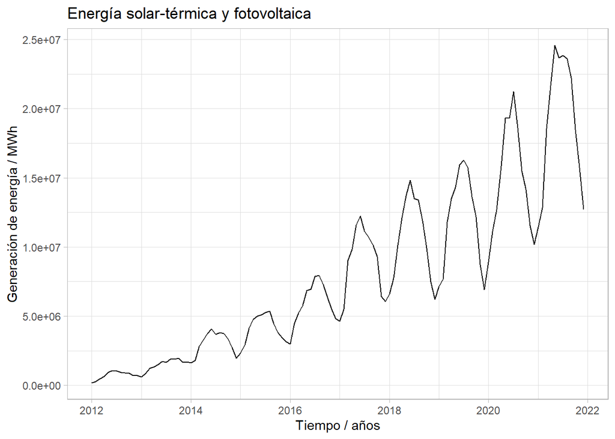

```r
autoplot(energy_source_ts, xlab = "Tiempo / años", ylab = "Generación de energía / MWh") +
  ggtitle(energy_source_label) +
  theme_light()
```

A partir del gráfico temporal podemos apreciar una cierta evolución en el largo plazo (*tendencia*): durante todos los años se observa una tendencia creciente. A partir de 2017, la serie temporal toma crece de forma proporcionalmente más lenta, pero se mantiene la tendencia. Además, podemos identificar un aumento en la variabilidad de los datos a lo largo del tiempo (*heterocedasticidad*). Por otro lado, se observa un comportamiento cíclico que se repite año tras año (*estacionalidad*), con una mayor generación de energía durante los meses de verano. La longitud del ciclo estacional es $c = 12$.

En este ejemplo, la estacionalidad de la serie se observa claramente en el gráfico temporal. No obstante, el diagrama de cajas por mes nos permite también valorar la presencia de estacionalidad.

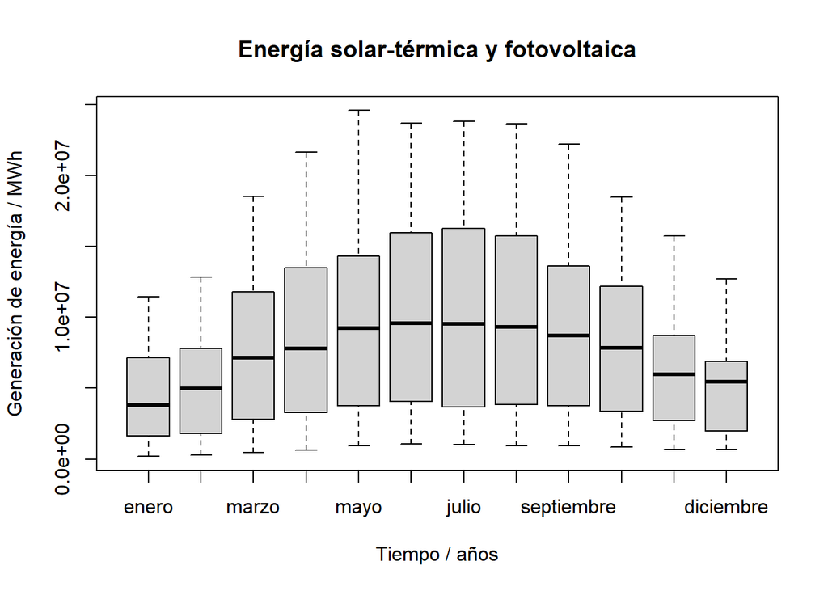

```r
energy_source_df <- energy_source_df %>%
  mutate(mes = format(date, "%B"))

energy_source_df$mes <- factor(energy_source_df$mes,
                       levels = c("enero", "febrero", "marzo", "abril", "mayo", "junio",
                                  "julio", "agosto", "septiembre", "octubre", "noviembre", "diciembre"))

# Ordenamos los meses para que los represente por orden temporal

boxplot(energy_source_df$gen.MWh ~ energy_source_df$mes, xlab = "Tiempo / años", ylab = "Generación de energía / MWh", main = energy_source_label)
```

Una gráfica estacional es similar a una gráfica temporal, excepto que los datos se dibujan contra las “estaciones” individuales en las que se observaron los datos. A continuación se ofrece un ejemplo:

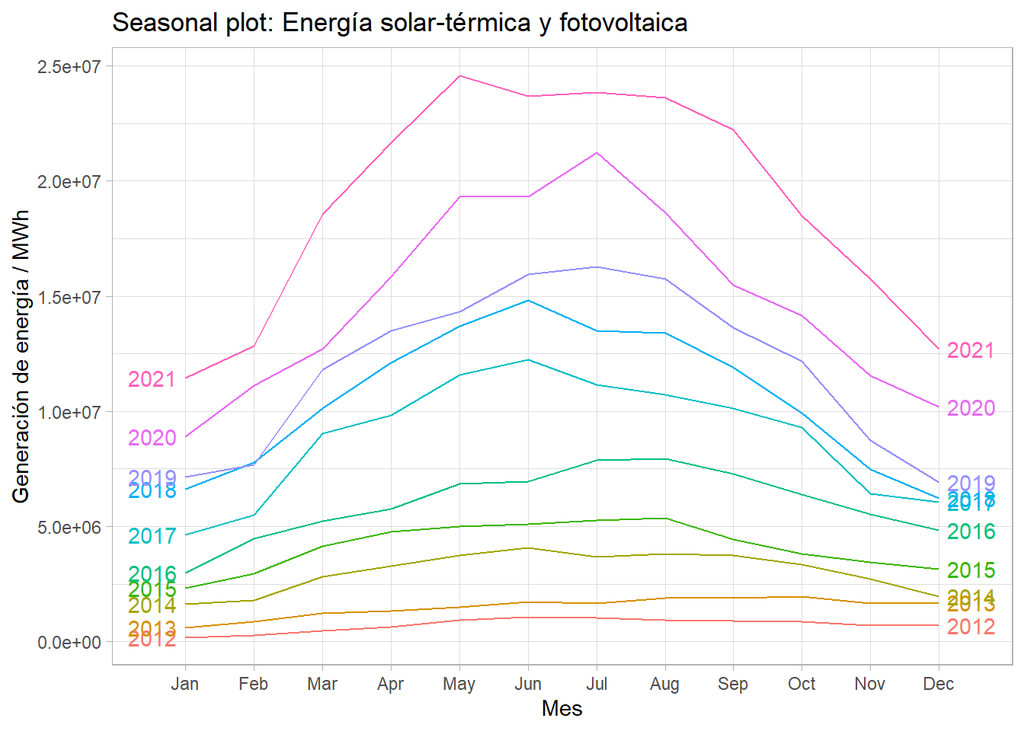

```r
ggseasonplot(energy_source_ts, year.labels = TRUE, year.labels.left = TRUE) +
  xlab("Mes") +
  ylab("Generación de energía / MWh") +
  ggtitle(paste("Seasonal plot:", energy_source_label)) +
  theme_light()
```

## 2.2 Análisis de la serie mediante suavizado exponencial

Dadas las características de la serie temporal: tendencia, estacionalidad y heterocedasticidad; el método adecuado para su análisis es el método de Holt-Winters.

Compararemos los resultados obtenidos a partir del método Holt-Winters aditivo, Holt-Winters multiplicativo, así como del Holt-Winters aditivo pero aplicado a la serie transformada (con logaritmo).

Utilizamos los datos hasta diciembre de 2020 para el ajuste y reservamos las observaciones de 2021 para valorar la capacidad predictiva del método seleccionado. La predicción para el año 2021 la realizaremos utilizando el método que nos proporciones un mejor ajuste.

### 2.2.1 Holt-Winters aditivo

Este método aditivo agrega el factor de estacionalidad a la previsión con tendencia, tal y como se vio en clase.

```r
insample <- window(energy_source_ts, start = c(2012,1), end = c(2020,12))
outsample <- window(energy_source_ts, start = c(2021,1), end = c(2021,12))

energy_source_HW_add <- HoltWinters(insample, seasonal="additive")
energy_source_HW_add$coefficients
```

```
##            a            b           s1           s2           s3           s4
## 10462733.653    65440.753  -413031.371  -234228.681    58171.036    65618.737
##           s5           s6           s7           s8           s9          s10
##   151455.571   305885.509   308714.119   169856.464   106108.939    -8591.253
##          s11          s12
##  -230070.417  -279888.653
```

```r
energy_source_HW_add$alpha
```

```
## alpha
##     1
```

```r
energy_source_HW_add$beta
```

```
## beta
##    0
```

```r
energy_source_HW_add$gamma
```

```
## gamma
##     1
```

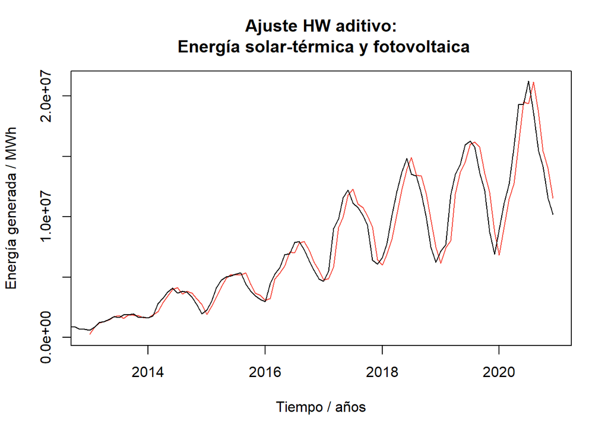

```r
fitval_add <- fitted(energy_source_HW_add)
# fitval contiene la serie de valores ajustados en la primera columna (fitval_add[,1] = xhat)

plot(energy_source_HW_add, xlab = x_label, ylab = y_label,
     main = paste("Ajuste HW aditivo:\n", energy_source_label))
```

```r
# Valoramos la bondad del ajuste
insamplecut <- window(insample, start = c(2013,1), end = c(2020,12))
# El año 2012 se utiliza para calcular las condiciones iniciales.
# El ajuste pues se obtiene a partir de enero de 2013.

rmse_add <- sqrt(mean( (insamplecut - fitval_add[,1]) ^ 2 ))
mape_add <- 100 * mean( abs(insamplecut - fitval_add[,1]) / insamplecut )
```

### 2.2.2 Holt-Winters multiplicativo

En este caso el factor de estacionalidad aparece multiplicando a la previsión con tendencia: de ahí el nombre del método.

```r
energy_source_HW_mult <- HoltWinters(insample, seasonal = "multiplicative")
energy_source_HW_mult$coefficients
```

```
##            a            b           s1           s2           s3           s4
## 1.493319e+07 2.401231e+05 7.274060e-01 8.509142e-01 1.068501e+00 1.278451e+00
##           s5           s6           s7           s8           s9          s10
## 1.464612e+00 1.493442e+00 1.529965e+00 1.370682e+00 1.152138e+00 1.024569e+00
##          s11          s12
## 7.821567e-01 6.550297e-01
```

```r
energy_source_HW_mult$alpha
```

```
##     alpha
## 0.1918343
```

```r
energy_source_HW_mult$beta
```

```
##       beta
## 0.09128748
```

```r
energy_source_HW_mult$gamma
```

```
##     gamma
## 0.6340169
```

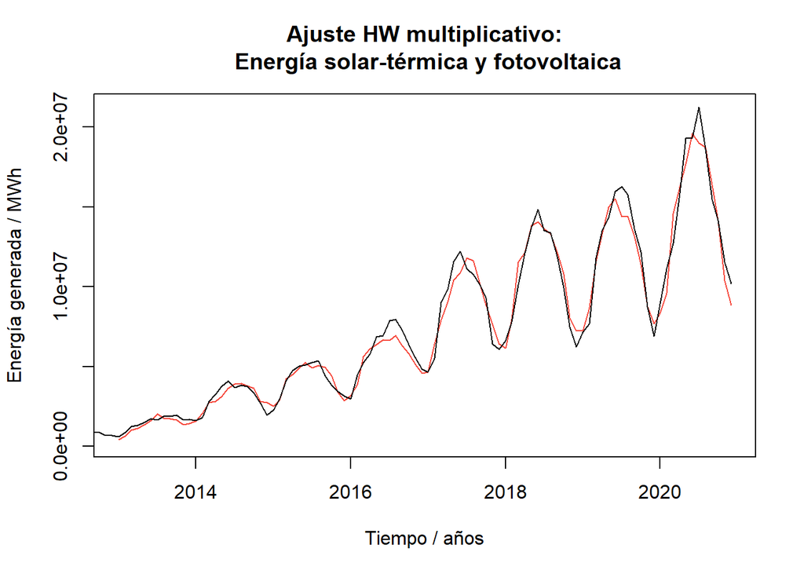

```r
fitval_mult <- fitted(energy_source_HW_mult)

plot(energy_source_HW_mult, xlab = x_label, ylab = y_label,
     main = paste("Ajuste HW multiplicativo:\n", energy_source_label))
```

```r
# Valoramos la bondad del ajuste
rmse_mult <- sqrt(mean( (insamplecut - fitval_mult[,1]) ^ 2 ))
mape_mult <- 100*mean( abs(insamplecut - fitval_mult[,1]) / insamplecut )
```

### 2.2.3 Holt-Winters aditivo aplicado a la serie transformada

Una alternativa al método multiplicativo consiste en realizar previamente una transformación logarítmica a los datos. La serie logarítmica se analiza con el método de Holt-Winters aditivo. A las predicciones obtenidas se les aplica una transformación exponencial para regresar a las unidades originales.

```r
loginsample <- log(insample)

energy_source_HW_log_add <- HoltWinters(loginsample, seasonal = "additive")
energy_source_HW_log_add$coefficients
```

```
##           a           b          s1          s2          s3          s4
## 16.62349643  0.01872548 -0.37270592 -0.22288437  0.05115333  0.19044481
##          s5          s6          s7          s8          s9         s10
##  0.27244382  0.26622830  0.24591005  0.16031021  0.02174685 -0.08828749
##         s11         s12
## -0.34691460 -0.49069663
```

```r
energy_source_HW_log_add$alpha
```

```
##     alpha
## 0.5010765
```

```r
energy_source_HW_log_add$beta
```

```
##       beta
## 0.06586033
```

```r
energy_source_HW_log_add$gamma
```

```
##    gamma
## 0.508682
```

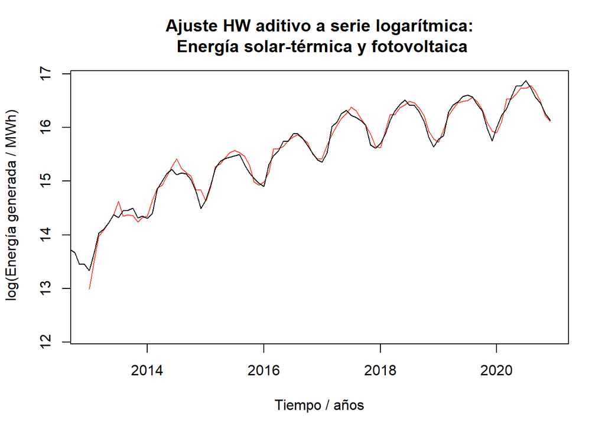

```r
fitval_log <- fitted(energy_source_HW_log_add)

plot(energy_source_HW_log_add, xlab = x_label, ylab = y_label_log,
     main = paste("Ajuste HW aditivo a serie logarítmica:\n", energy_source_label))
```

```r
# Valoramos la bondad del ajuste. Para ello, volvemos previamente a la escala original

fitval_ori <- exp(fitval_log[,1])

rmse_log <- sqrt(mean( (insamplecut - fitval_ori) ^ 2 ))
mape_log <- 100*mean( abs(insamplecut - fitval_ori) / insamplecut )
```

### 2.2.4 Construcción de la Tabla de resultados obtenidos con los distintos métodos

```r
error_ajuste <- matrix(c(rmse_add, mape_add, rmse_mult, mape_mult, rmse_log, mape_log), nrow = 3, byrow = TRUE)
rownames(error_ajuste) <- c("Aditivo", "Multiplicativo", "Log-Aditivo")
colnames(error_ajuste) <- c("RMSE / MWh", "MAPE / %")
kable(error_ajuste, caption = "Tabla 3. Resultados obtenidos con los distintos métodos de suavizado", align = "c")
```

Tabla 3. Resultados obtenidos con los distintos métodos de suavizado

|  | RMSE / MWh | MAPE / % |
| --- | --- | --- |
| Aditivo | 1297468.5 | 12.004366 |
| Multiplicativo | 715723.2 | 8.578600 |
| Log-Aditivo | 833149.8 | 8.589788 |

El método con menor error de ajuste (tanto RMSE como MAPE) es Holt-Winters con estacionalidad multiplicativa. Este será, por tanto, el método utilizado para calcular la predicción para el año 2021.

### 2.2.5 Selección del mejor método para realizar la predicción

El método escogido es el Holt-Winters multiplicativo por lo que se comentó anteriormente.

```r
# Elegimos el HW a usar
energy_source_HW <- energy_source_HW_mult

pred <- predict(energy_source_HW, 12)
# Valoramos la capacidad predictiva del método
rmse_pred <- sqrt(mean( (outsample - pred) ^ 2 ))
mape_pred <- 100 * mean( abs(outsample - pred) / outsample )

cat("Predicción para 2021:\nRMSE:", rmse_pred, "\nMAPE:", mape_pred, "%\n")
```

```
## Predicción para 2021:
## RMSE: 1342167
## MAPE: 6.170981 %
```

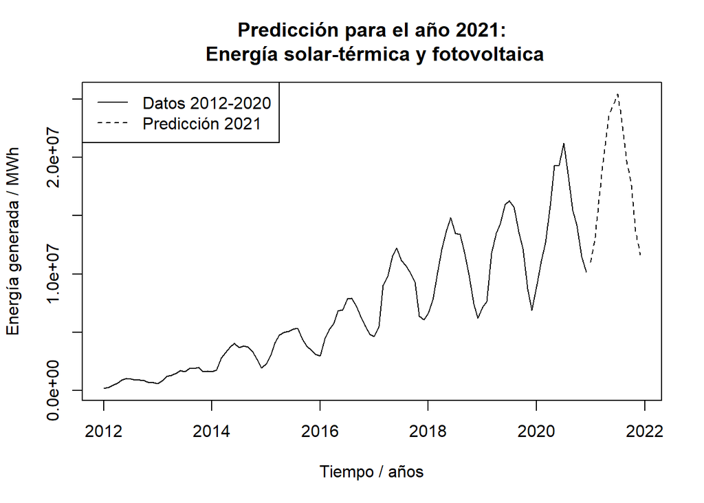

```r
# pred contiene las predicciones puntuales para los 12 meses de 2021
ts.plot(insample, pred, lty = 1:2,
        gpars = list(xlab = x_label, ylab = y_label,
                     main = paste("Predicción para el año 2021:\n", energy_source_label)))
legend("topleft", legend = c("Datos 2012-2020", "Predicción 2021"),
       lty = c(1, 2))
```

Podemos también representar gráficamente los valores reales de 2021 que habíamos reservado junto con la predicción puntual:

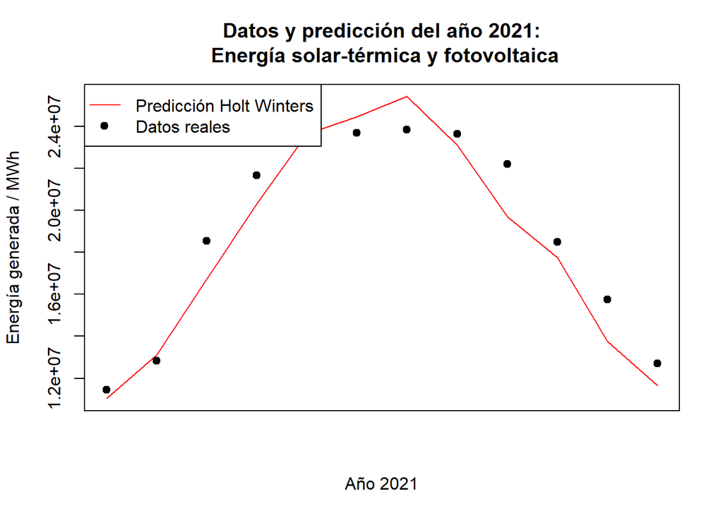

```r
plot(pred, col = "red", xaxt = "n", xlab = "Año 2021", ylab = y_label,
     main = paste("Datos y predicción del año 2021:\n", energy_source_label))
points(outsample, pch = 19)
legend("topleft", legend = c("Predicción Holt Winters", "Datos reales"),
       col = c("red", "black"), pch = c(NA, 19), lty = c(1, 0))
```

De nuevo, al igual que en el caso de la energía total, los puntos reales no distan demasiado a simple vista de lo que ofrece nuestra predicción Holt-Winters.

Así mismo, es posible determinar el intervalo de predicción al 95% en nuestro modelo, como se muestra en la siguiente Figura.

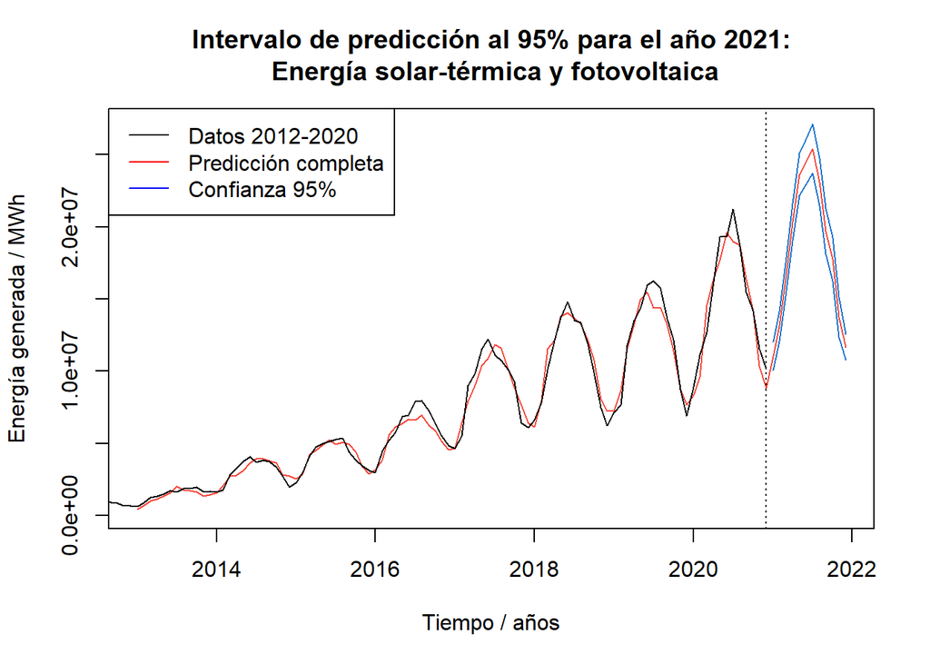

```r
pred <- predict(energy_source_HW, n.ahead = 12, prediction.interval = TRUE, level = 0.95)
plot(energy_source_HW, pred, xlab = x_label, ylab = y_label,
     main = paste("Intervalo de predicción al 95% para el año 2021:\n", energy_source_label))
legend("topleft", legend = c("Datos 2012-2020", "Predicción completa", "Confianza 95%"),
       col = c("black", "red", "blue"), lty = 1)
```

## 2.3 Análisis de la serie mediante la metodología Box-Jenkins

Con la metodología Box-Jenkins la idea es describir el valor observado en un período t como una función lineal de valores anteriores y errores debidos al azar.

### 2.3.1 Transformación estacionaria de la serie

Con objetivo de quitar la heterocedasticidad aplicamos la función logaritmo primeramente.

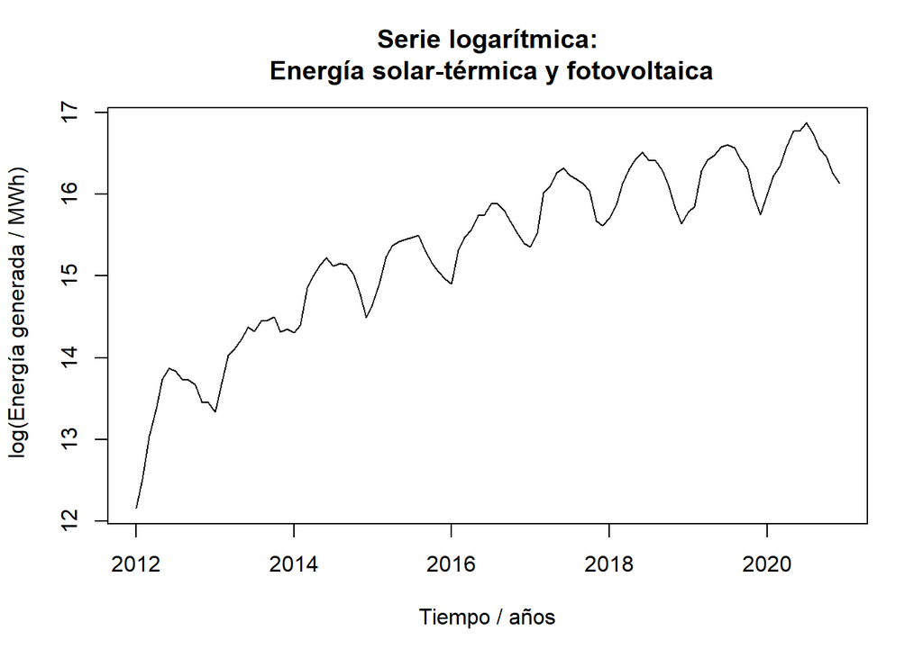

```r
loginsample <- log(insample)
plot(loginsample, xlab = x_label, ylab = y_label_log,
     main = paste("Serie logarítmica:\n", energy_source_label))
```

Hemos conseguido eliminar la heterocedasticidad a la vista de lo obtenido.

Ahora,se procede a calcular una diferencia estacional ($D = 1$):

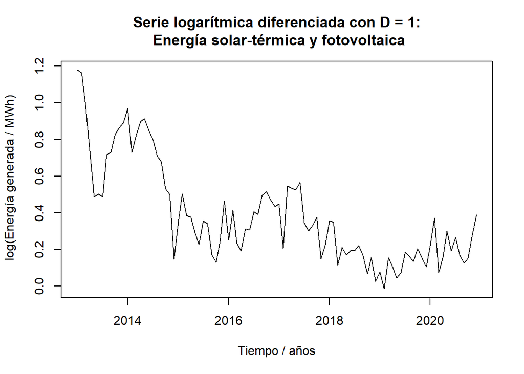

```r
d12insample <- diff(loginsample, 12)
plot(d12insample, xlab = x_label, ylab = y_label_log,
     main = paste("Serie logarítmica diferenciada con D = 1:\n", energy_source_label))
```

Probamos ahora la diferencia regular ($d = 1$):

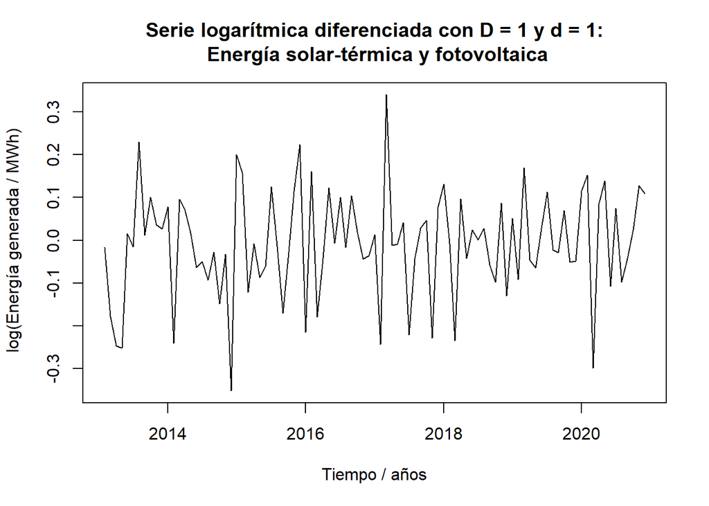

```r
dd12insample <- diff(d12insample)
plot(dd12insample, xlab = x_label, ylab = y_label_log,
     main = paste("Serie logarítmica diferenciada con D = 1 y d = 1:\n", energy_source_label))
```

Podemos asumir que la serie logarítmica diferenciada con $d = 1$ y $D = 1$ ya es estacionaria para proseguir con nuestro análisis más detallado.

### 2.3.2 Identificación de un modelo basado en análisis de autocorrelaciones y autocorrelaciones parciales

Pasamos a examinar el correlograma y el correlograma parcial:

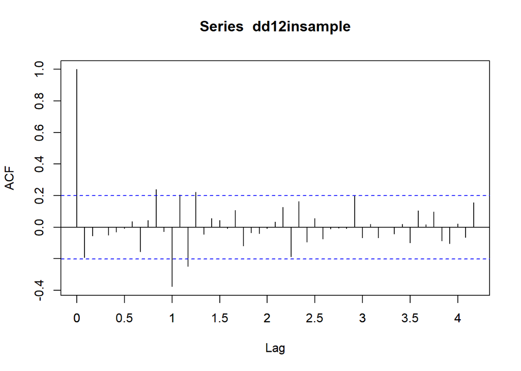

```r
acf_result <- acf(dd12insample,lag.max = 50, plot = FALSE)

plot(acf_result)
custom_xticks <- seq(0, 5, by = 0.5)
axis(1, at = custom_xticks, labels = custom_xticks)
```

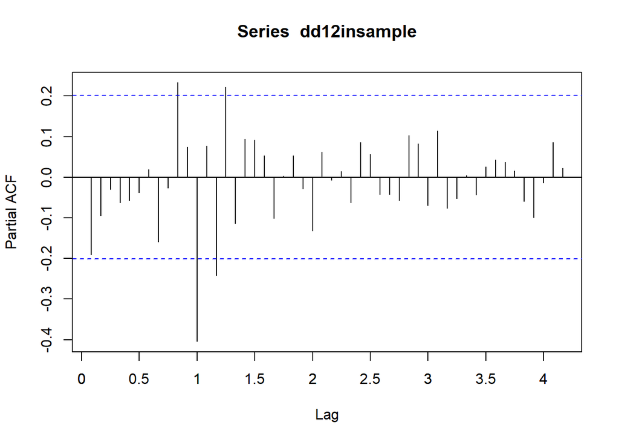

```r
pacf_result <- pacf(dd12insample,lag.max = 50, plot = FALSE)
plot(pacf_result)
custom_xticks <- seq(0, 5, by = 0.5)
axis(1, at = custom_xticks, labels = custom_xticks)
```

Veamos el ajuste proporcionado por los distintos modelos:

**Modelo 1.**

```r
source_energy_model_1 <- arima(loginsample, order = c(0,1,0), seasonal = list(order=c(0,1,1), period=12))
source_energy_model_1
```

```
##
## Call:
## arima(x = loginsample, order = c(0, 1, 0), seasonal = list(order = c(0, 1, 1),
##     period = 12))
##
## Coefficients:
##          sma1
##       -0.6930
## s.e.   0.1137
##
## sigma^2 estimated as 0.01094:  log likelihood = 75.78,  aic = -147.56
```

```r
#Modelo 1: p values
source_energy_model_1s <- sarima(loginsample,0,1,0,0,1,1,12, details = FALSE)
source_energy_model_1s$ttable
```

```
##      Estimate     SE t.value p.value
## sma1   -0.693 0.1137 -6.0969       0
```

**Modelo 2.**

```r
source_energy_model_2 <- arima(loginsample, order = c(1,1,1), seasonal = list(order = c(0,1,1), period=12))
source_energy_model_2
```

```
##
## Call:
## arima(x = loginsample, order = c(1, 1, 1), seasonal = list(order = c(0, 1, 1),
##     period = 12))
##
## Coefficients:
##          ar1      ma1     sma1
##       0.0834  -0.2272  -0.6606
## s.e.  0.4664   0.4548   0.1132
##
## sigma^2 estimated as 0.01083:  log likelihood = 76.7,  aic = -145.4
```

```r
#Modelo 2: p values
source_energy_model_2s <- sarima(loginsample,1,1,1,0,1,1,12, details = FALSE)
source_energy_model_2s$ttable
```

```
##      Estimate     SE t.value p.value
## ar1    0.0834 0.4664  0.1789  0.8584
## ma1   -0.2272 0.4548 -0.4995  0.6186
## sma1  -0.6606 0.1132 -5.8358  0.0000
```

**Modelo predicho por Auto-Arima**

```r
source_energy_model_auto <- auto.arima(loginsample)
source_energy_model_auto
```

```
## Series: loginsample
## ARIMA(0,1,0)(0,1,1)[12]
##
## Coefficients:
##          sma1
##       -0.6930
## s.e.   0.1137
##
## sigma^2 = 0.01107:  log likelihood = 75.78
## AIC=-147.56   AICc=-147.43   BIC=-142.46
```

El modelo de menor AIC es (p,d,q)(P,D,Q) = (0,1,0)(0,1,1), que coincide con el modelo proporcionado por la función `auto.arima`. Los estadísticos asociados a este modelo son:

```
##                       ME       RMSE        MAE        MPE      MAPE      MASE
## Training set -0.02154707 0.09816703 0.07159265 -0.1419683 0.4635224 0.4881224
##                  ACF1
## Training set -0.19422
```